# 11/19

Bo Jumrustanasan

### Last time

- Use fitted lines to predict missing house numbers.
- Break into sequences to avoid overly complex fitted lines
- Then regress house numbers on indices

### Sequence breaking function

- Takes in the census dataframe.
- Returns a list of indices where new sequences start
- The list of indices is applied on the dataframe to group records into sequences
- Each sequence gets a unique sequence id, starting from 1
- how it does:
  - odd VS even
  - decreasing VS increasing
  - distance to previous and after HNs
- more improvement can be made for a better precision

### Actual Code

[see getSequence.R]

- getSequenceHead(): knows which HH recordd are sequence heads
- appendSeqCol(): assigns unique number for each sequence (new column)

### How it is doing: sequences

- House_num and index colored by sequence id
- Long missing house number gap after index 540

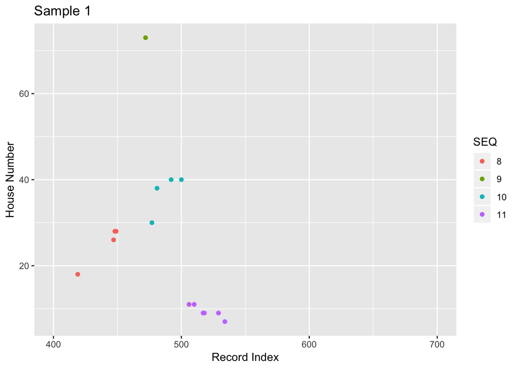

- Repeated house numbers after index 3170
- Outlier at house number ~ 3000

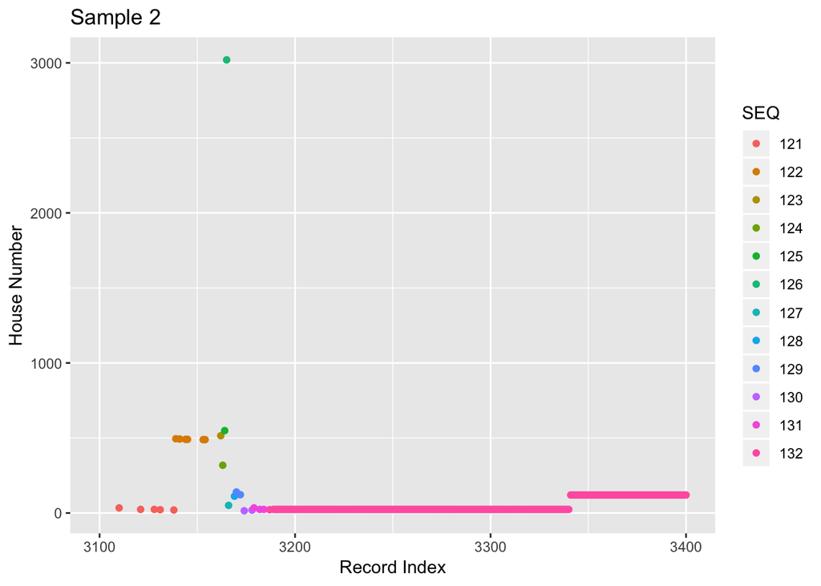

### How it is doing: HH records

- Counts of records in a sequence
- One sequence has more than 500 HH records in it (SEQ153).

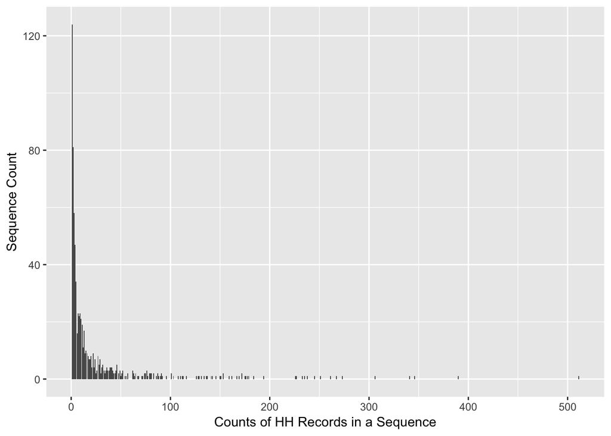

- What does it like on the page?
- With missing `house_num` and `street_add` gaps in the middle. This seems like a valid sequence (from 92 to 118) except that both records with available house numbers have different street names
- Can we handle house numbers completely independently from street names?

```
##   house_num    street_add SEQ
## 1       130 LACURD STREET 152
## 2        NA LACURD STREET 152
## 3        NA LACURD STREET 152
## 4        NA LACURD STREET 152
## 5       132 LACURD STREET 152
## 6        NA LACURD STREET 152
## 7       132 LACURD STREET 152
## 8        NA LACURD STREET 152
```

```
##   house_num   street_add SEQ
## 1        92 LAFAYETTE ST 153
## 2        NA              153
```

```
##     house_num street_add SEQ
## 510        NA            153
## 511       118  GARTER ST 153
```

```
##   house_num street_add SEQ
## 1        71  GARTER ST 154
## 2        NA  GARTER ST 154
```

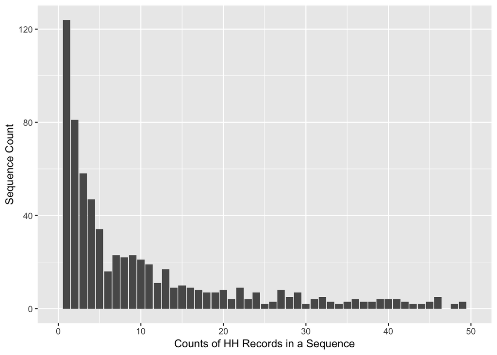

- EXAMPLE1: see SEQ30. It also seems like a good sequence break given previous and next sequences.

```
##   house_num   street_add SEQ
## 1        31 JAMES STREET  29
## 2        NA JAMES STREET  29
## 3        33 JAMES STREET  29
## 4        37 JAMES STREET  29
## 5        NA JAMES STREET  29
## 6        47   NEW BOWERY  29
## 7        NA   NEW BOWERY  29
## 8        NA   NEW BOWERY  29
```

```
##   house_num    street_add SEQ
## 1        31 OLIVER STREET  30
```

```
##   house_num     street_add SEQ
## 1        43 MADISON STREET  31
## 2        NA MADISON STREET  31
```

- EXAMPLE2: Another sequence with 1 HH record (SEQ45).

```
##    house_num   street_add SEQ
## 1          9 HENRY STREET  44
## 2         NA HENRY STREET  44
## 3         NA HENRY STREET  44
## 4         NA HENRY STREET  44
## 5         NA HENRY STREET  44
## 6         NA HENRY STREET  44
## 7         NA HENRY STREET  44
## 8         NA HENRY STREET  44
## 9         NA HENRY STREET  44
## 10        NA HENRY STREET  44
## 11        NA HENRY STREET  44
## 12        NA HENRY STREET  44
## 13        NA HENRY STREET  44
```

```
##   house_num    street_add SEQ
## 1         2 OLIVER STREET  45
```

```
##   house_num     street_add SEQ
## 1        23 CHATHAM SQUARE  46
## 2        NA CHATHAM SQUARE  46
## 3        NA CHATHAM SQUARE  46
```

### How it is doing: house number

- Counts of house_num in a sequence
- A few sequences have more than 200 house numbers in one sequence

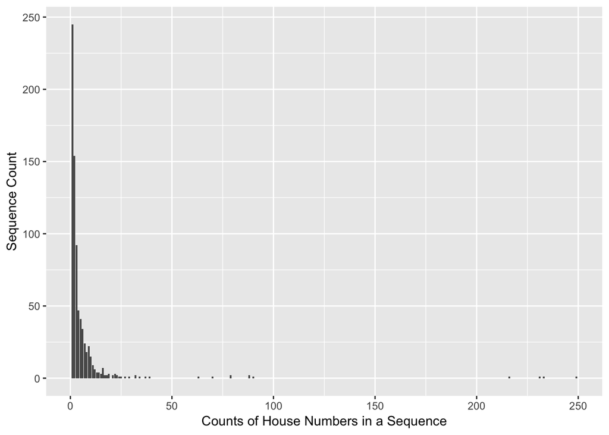

- EXAMPLE1:

| house_num | street_add | SEQ |
| --- | --- | --- |
| 430 | PEARL STREET | 5 |
| NA | PEARL STREET | 5 |
| NA | PEARL STREET | 5 |
| 432 | PEARL STREET | 5 |
| NA | PEARL STREET | 5 |
| 432 |  | 5 |
| NA |  | 5 |
| NA |  | 5 |
| NA |  | 5 |
| NA |  | 5 |
| NA |  | 5 |
| NA |  | 5 |
| NA |  | 5 |
| NA |  | 5 |
| NA |  | 5 |
| NA |  | 5 |
| 432 |  | 5 |
| 432 |  | 5 |
| NA |  | 5 |
| NA |  | 5 |
| NA |  | 5 |
| NA |  | 5 |
| NA |  | 5 |
| 434 |  | 5 |
| NA |  | 5 |
| NA |  | 5 |
| NA |  | 5 |
| NA |  | 5 |
| NA |  | 5 |
| 434 | CARL STREET | 5 |

[output cut: 243 more lines]

- EXAMPLE2:

| house_num | street_add | SEQ |
| --- | --- | --- |
| 5 | BAXTER STREET | 211 |
| 5 | BAXTER STREET | 211 |
| 5 | BAXTER STREET | 211 |
| 5 | BAXTER STREET | 211 |
| 5 | BAXTER STREET | 211 |
| 5 | BAXTER STREET | 211 |
| 5 | BAXTER STREET | 211 |
| 5 | BAXTER STREET | 211 |
| 5 | BAXTER STREET | 211 |
| 5 | BAXTER STREET | 211 |
| 5 | BAXTER STREET | 211 |
| 5 | BAXTER STREET | 211 |
| 5 | BAXTER STREET | 211 |
| 5 | BAXTER STREET | 211 |
| 5 | BAXTER STREET | 211 |
| 5 | BAXTER STREET | 211 |
| 5 | BAXTER STREET | 211 |
| 5 | BAXTER STREET | 211 |
| 5 | BAXTER STREET | 211 |
| 5 | BAXTER STREET | 211 |
| 5 | BAXTER STREET | 211 |
| 5 | BAXTER STREET | 211 |
| 5 | BAXTER STREET | 211 |
| 5 | BAXTER STREET | 211 |
| 5 | BAXTER STREET | 211 |
| 5 | BAXTER STREET | 211 |
| 5 | BAXTER STREET | 211 |
| 5 | BAXTER STREET | 211 |
| 5 | BAXTER STREET | 211 |
| 5 | BAXTER STREET | 211 |

[output cut: 203 more lines]

- almost 250 sequences have only one house numbers.

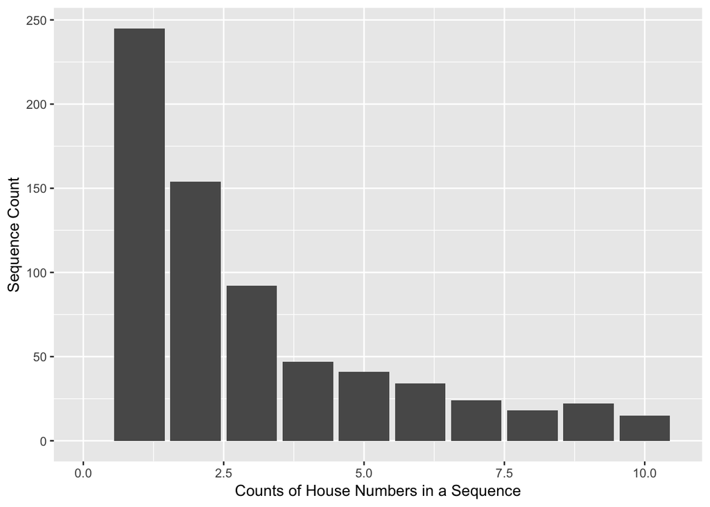

- SEQ164 has only 1 house number but with 3 HH records.
- Confident if there are a small number of HH records.

```
##   house_num street_add SEQ
## 1         8 HUIKAHI ST 164
## 2        NA HUIKAHI ST 164
## 3        NA HUIKAHI ST 164
```

- But could be worrisome when a sequence has *many HH records* but *few house numers*.

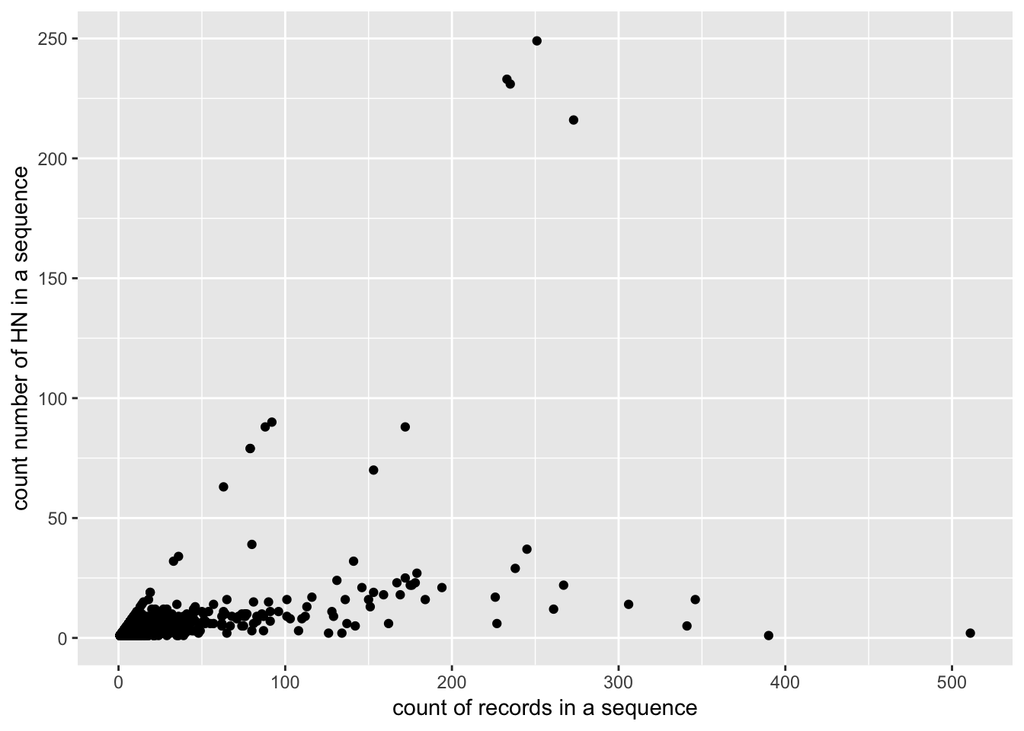

- SEQ15 has 126 records with 2 house numbers.

| house_num | street_add | SEQ |
| --- | --- | --- |
| 11 | JAMES STREET | 15 |
| NA | JAMES STREET | 15 |
| NA | JAMES STREET | 15 |
| NA | JAMES STREET | 15 |
| NA | JAMES STREET | 15 |
| NA | JAMES STREET | 15 |
| NA | JAMES STREET | 15 |
| NA | JAMES STREET | 15 |
| NA | JAMES STREET | 15 |
| NA | JAMES STREET | 15 |
| NA | JAMES STREET | 15 |
| NA | JAMES STREET | 15 |
| NA | JAMES STREET | 15 |
| NA | JAMES STREET | 15 |
| NA | JAMES STREET | 15 |
| NA | JAMES STREET | 15 |
| NA | JAMES STREET | 15 |
| NA | JAMES STREET | 15 |
| NA | JAMES STREET | 15 |
| NA | JAMES STREET | 15 |
| NA | JAMES STREET | 15 |
| NA | JAMES STREET | 15 |
| NA | JAMES STREET | 15 |
| NA | JAMES STREET | 15 |
| NA | JAMES STREET | 15 |
| NA | JAMES STREET | 15 |
| NA | JAMES STREET | 15 |
| NA | JAMES STREET | 15 |
| NA | JAMES STREET | 15 |
| NA | JAMES STREET | 15 |

[output cut: 96 more lines]

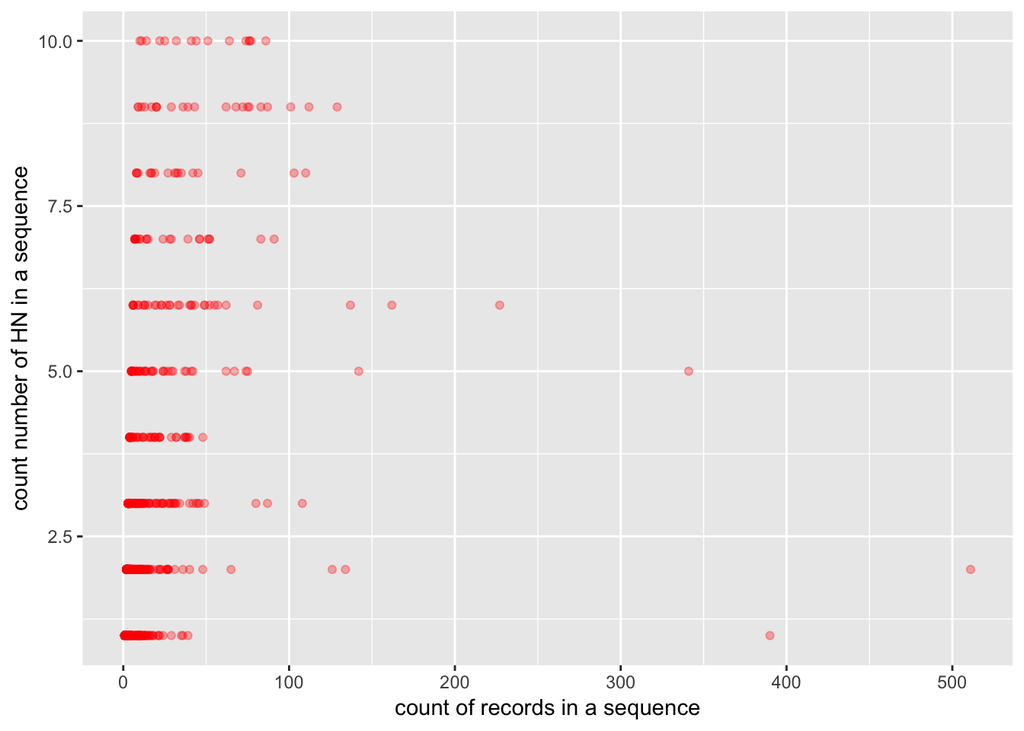

## Next Step

### Try fitting a linear line to a random sequence.

- SEQ 67
- Red are predictions for missing house numbers
- Blue are actual house numbers
- Predictions are rounded to the closest even (or odd depending on the parity of the current sequence) integer
  - See `roundHouseNum()` and `fillHN()` in `House/roundHouseNum.R`

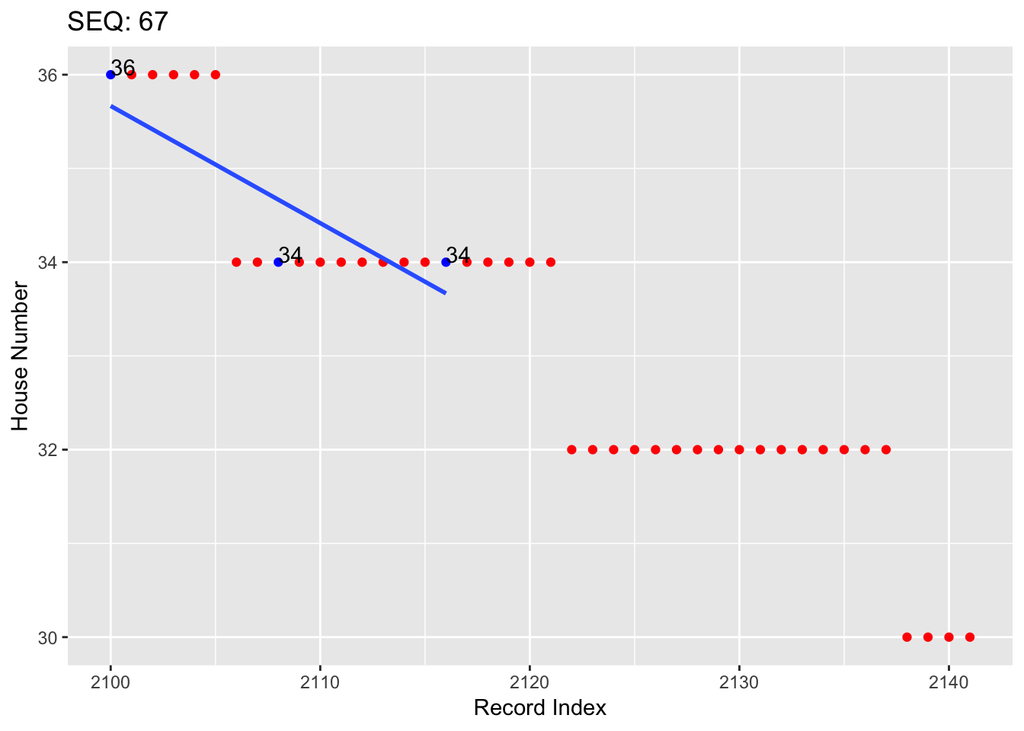

- Some sequences are broken after the fill in (SEQ17)

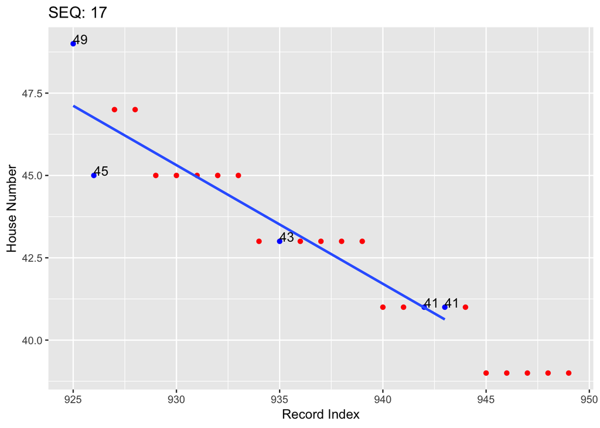

- Out of 759 sequences, filling in using fitted linear lines breaks 160 sequences.
- 0 means not broken sequence. 1 means broken sequence

| . | Freq |
| --- | --- |
| 0 | 599 |
| 1 | 160 |

### Try fitting a non-linear line to a random sequence.

- Last time I mentioned non-linear regression
- May not be viable because it requires a specific/unique regression function for each of the sequences

### What do we do with broken sequences?**

- There are ~760 sequences from 100k records
- About ~160 of them are broken
- Too much to handle manually?
- What if we drop the regression approach and linearly fill in like this:

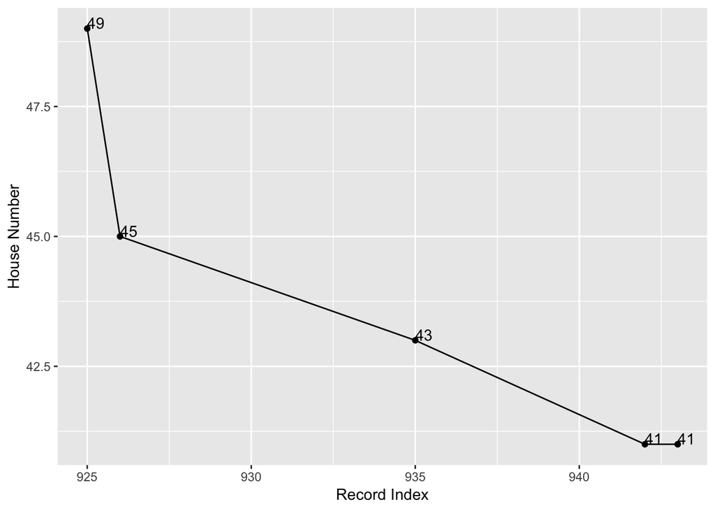

- Pro
  - assuming sequence breaker does a job well, there will be no broken sequences
- Con
  - one time expensive computation (I have not tried)

### To-do

- Better documented process and functions
- Place the second (and the third) house numbers from house number ranges somewhere in `house_num`:
  - Head and tail of a sequence?
- Add flags to some sequence break points:
  - Those with 1 record in a sequence?